# Vaccination scenarios and cost effectiveness analysis

Hikaru Bolt

24 July 2025 15:37

```r
# To run this
# rmarkdown::render("R/figures.R", output_dir = ".", intermediates_dir = ".", output_file = paste0("figures", paste0(gsub("-", "", tolower(Sys.Date())), "_", format(Sys.time(), "%H%M"))))

knitr::opts_chunk$set(echo = FALSE,
                      warning = FALSE,
                      message = FALSE)
```

# Parameter distributions

```
## [1] "Alpha: 19.2"
## [1] "Beta: 133.4"
```

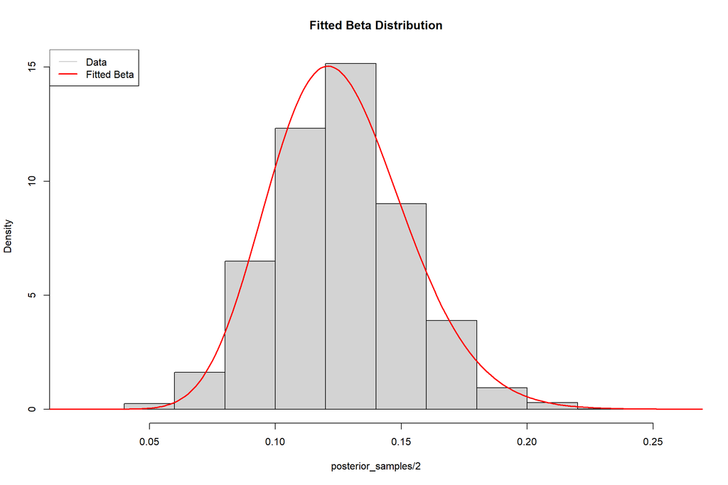

```
## [1] "Alpha: 389.9"
## [1] "Beta: 8377.2"
```

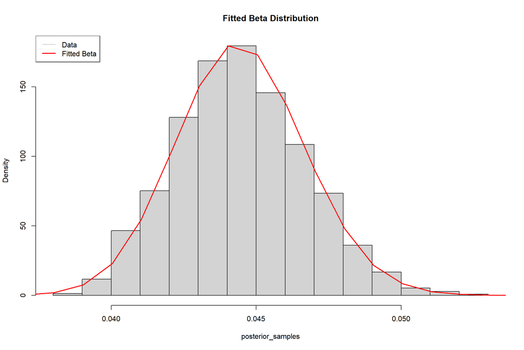

```
## [1] "Alpha: 389.9"
## [1] "Beta: 8377.2"
## [1] "Alpha: 15.3"
## [1] "Beta: 13937.7"
## [1] "Alpha: 8"
## [1] "Beta: 3819.9"
## [1] "Alpha: 40.5"
## [1] "Beta: 12223.3"
## [1] "Alpha: 61.4"
## [1] "Beta: 153540.1"
## [1] "Alpha: 61.4"
## [1] "Beta: 236282.2"
## [1] "Alpha: 44.4"
## [1] "Beta: 1143.3"
```

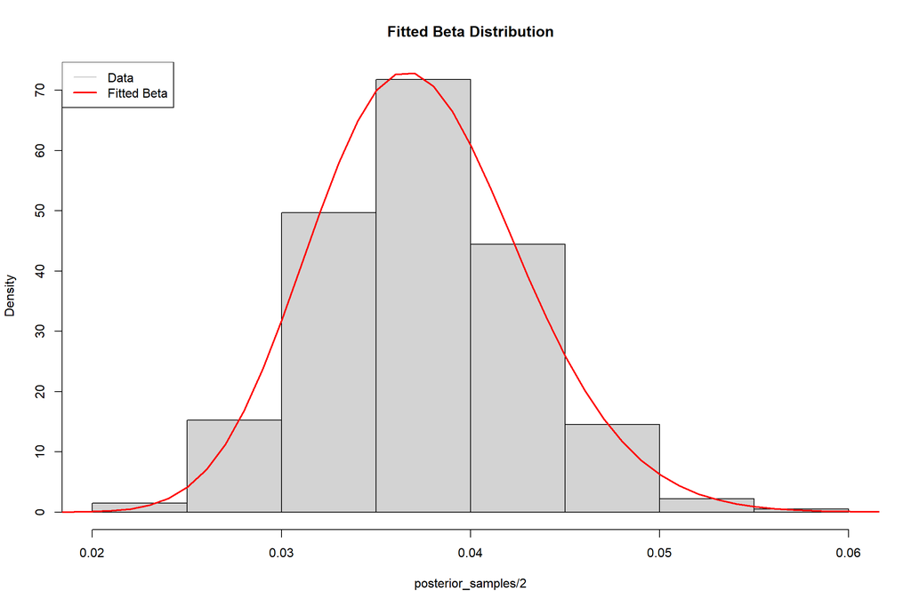

```
## [1] "Alpha: 1.7"
## [1] "Beta: 49.4"
## [1] "Alpha: 1.7"
## [1] "Beta: 49.4"
## [1] "Alpha: 1.1"
## [1] "Beta: 14.9"
## [1] "Alpha: 5.1"
## [1] "Beta: 17.7"
## [1] "Alpha: 600.2"
## [1] "Beta: 96038798.5"
## [1] "Alpha: 681"
## [1] "Beta: 146136237"
## [1] "Alpha: 593.2"
## [1] "Beta: 1362972.4"
## [1] "Alpha: 20.3"
## [1] "Beta: 7900.9"
## [1] "Alpha: 85.9"
## [1] "Beta: 11925.3"
## [1] "Alpha: 4"
## [1] "Beta: 813.2"
## [1] "Alpha: 94.1"
## [1] "Beta: 15.3"
## [1] "Alpha: 146.1"
## [1] "Beta: 665.4"
## [1] "Alpha: 247.9"
## [1] "Beta: 5793.8"
```

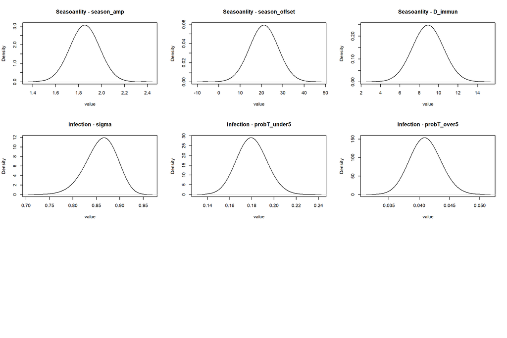

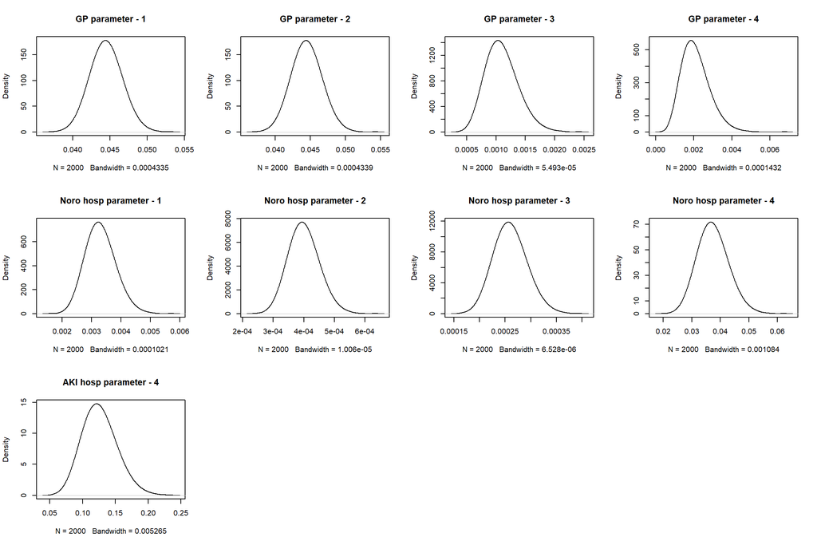

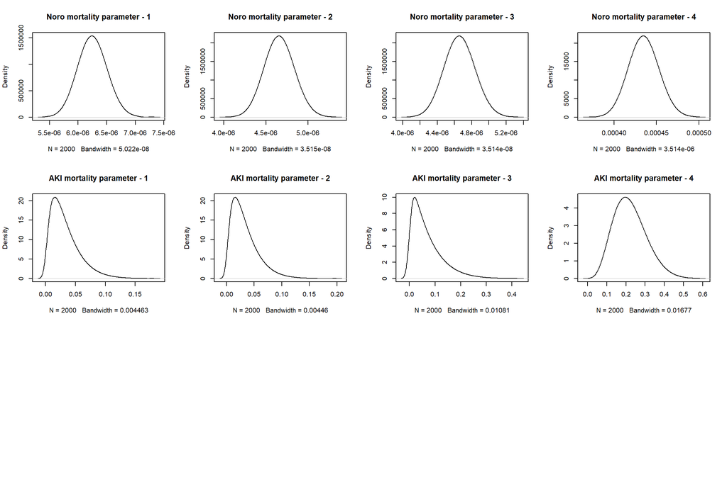

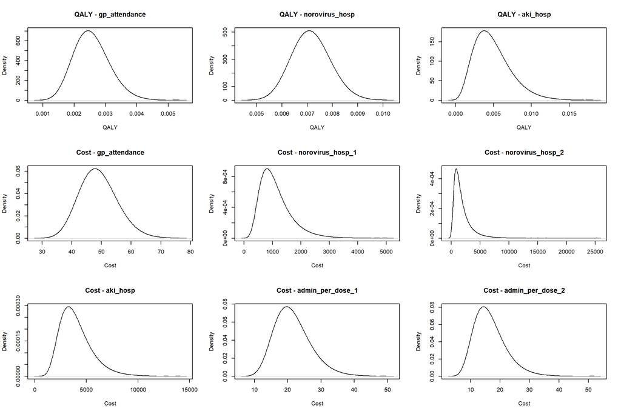

# Impact of vaccine efficacy on the number of symptomatic individuals

A. Symptomatic cases under 5 B. Symptomatic cases between 5 and 64 c. Symptomatic cases over 65 ## Percentage of symptomatic cases averted by vaccination scenarios

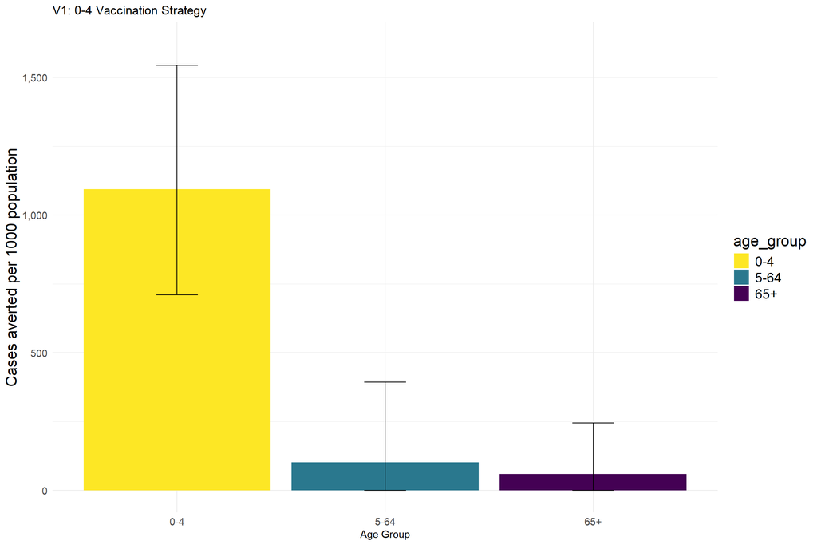

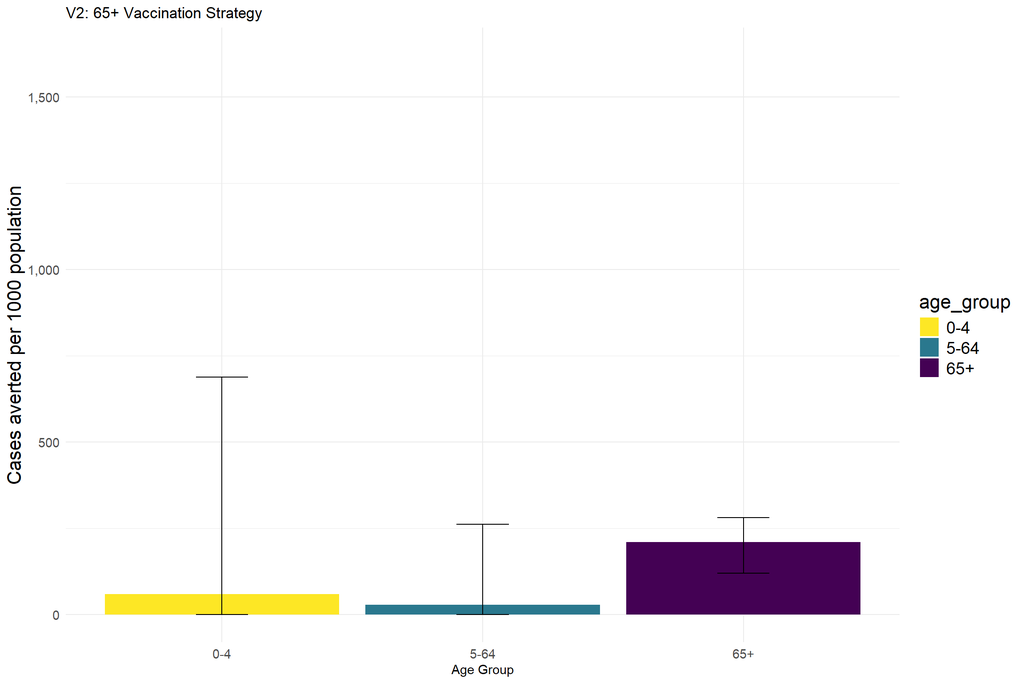

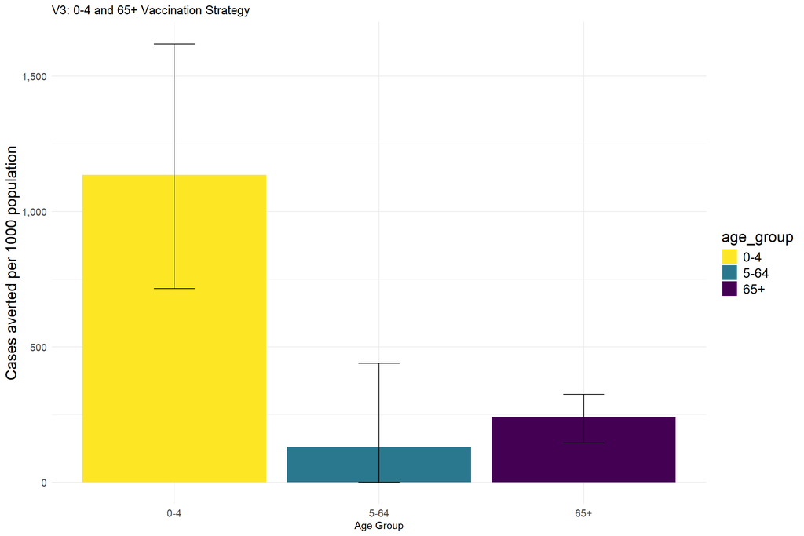

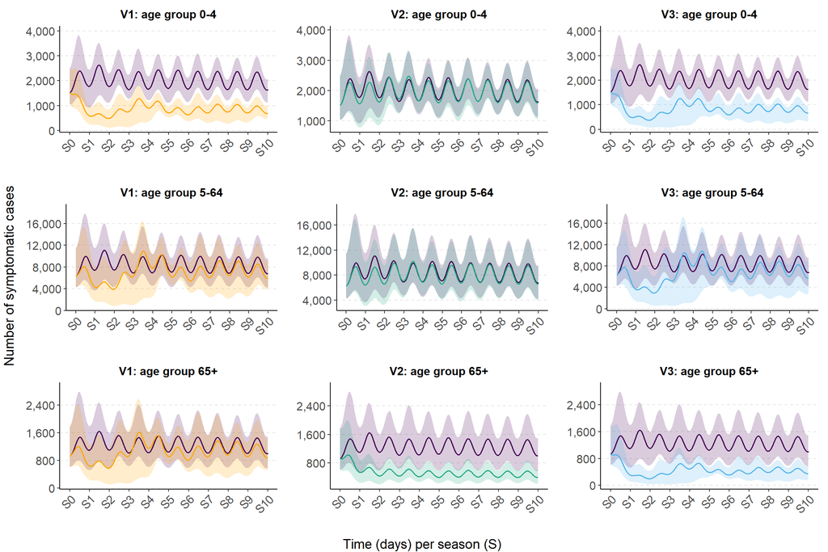

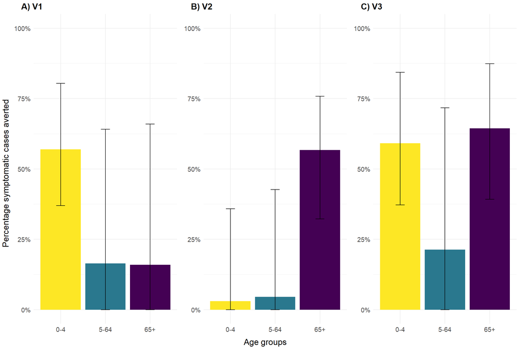

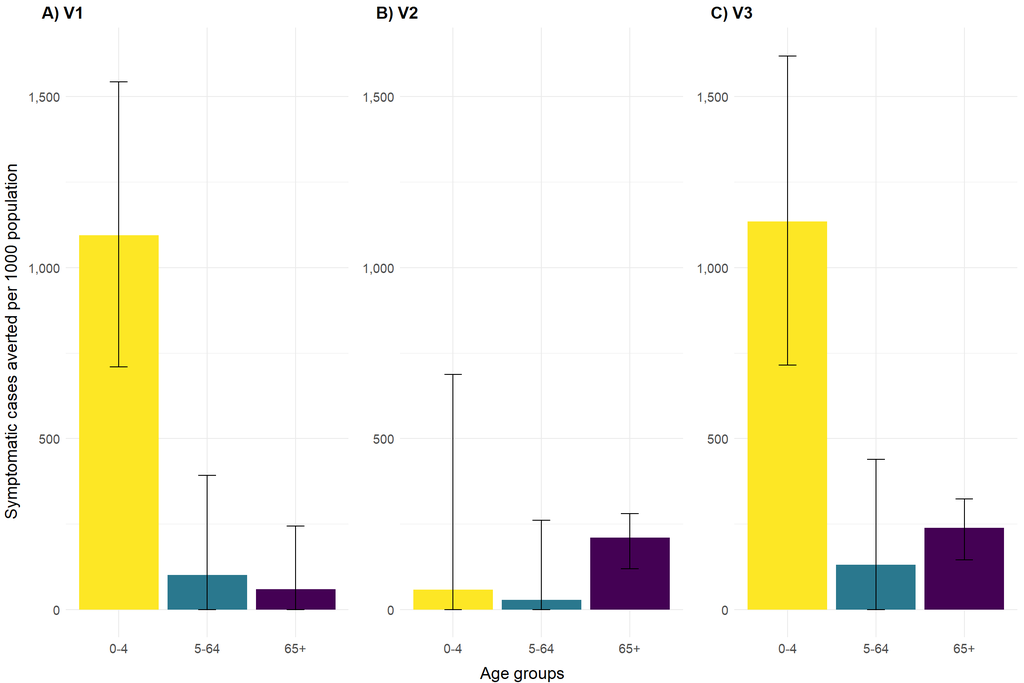

| Strategy | Age group | Total vaccinated | Infections total | GP attendance | Norovirus hospitalisation | Norovirus mortality | AKI hospitalisation | AKI mortality |
| --- | --- | --- | --- | --- | --- | --- | --- | --- |
| No vaccination |  |  |  |  |  |  |  |  |
|  | 0-4 | 0 (0-0) | 7,403,589 (5,330,021-9,262,348) | 329,278 (231,967-424,664) | 24,417 (15,283-34,924) | 46 (33-58) | Not applicable | Not applicable |
|  | 5-14 | 0 (0-0) | 6,155,107 (4,013,639-8,461,206) | 273,692 (180,100-374,632) | 2,462 (1,493-3,667) | 29 (19-40) | Not applicable | Not applicable |
|  | 15-64 | 0 (0-0) | 24,802,299 (15,519,309-34,829,287) | 27,282 (12,897-47,731) | 6,451 (3,689-9,810) | 116 (72-162) | Not applicable | Not applicable |
|  | 65+ | 0 (0-0) | 4,586,029 (2,683,496-6,796,203) | 9,627 (3,640-19,805) | 171,358 (93,166-273,001) | 1,995 (1,162-2,978) | 577,343 (277,705-1,002,972) | 127,658 (35,985-285,089) |
| V1 |  |  |  |  |  |  |  |  |
|  | 0-4 | 12,757,253 (12,722,958-12,789,221) | 3,184,235 (1,779,125-4,458,134) | 141,628 (77,888-201,239) | 10,500 (5,510-16,219) | 20 (11-28) | Not applicable | Not applicable |
|  | 5-14 | 0 (0-0) | 4,940,340 (2,596,427-7,261,877) | 219,665 (115,543-321,188) | 1,976 (996-3,108) | 23 (12-34) | Not applicable | Not applicable |
|  | 15-64 | 0 (0-0) | 20,926,634 (10,241,585-31,707,407) | 23,017 (9,333-42,360) | 5,444 (2,530-8,851) | 97 (48-147) | Not applicable | Not applicable |
|  | 65+ | 0 (0-0) | 3,854,751 (1,753,002-6,119,769) | 8,091 (2,601-17,282) | 144,000 (65,147-242,622) | 1,677 (764-2,682) | 485,242 (200,489-886,041) | 107,174 (27,731-245,014) |
| V2 |  |  |  |  |  |  |  |  |
|  | 0-4 | 0 (0-0) | 7,179,001 (5,098,808-9,077,272) | 319,290 (221,198-415,652) | 23,676 (14,507-34,212) | 45 (32-57) | Not applicable | Not applicable |
|  | 5-14 | 0 (0-0) | 5,946,344 (3,812,919-8,259,806) | 264,407 (170,483-365,529) | 2,378 (1,409-3,576) | 28 (18-39) | Not applicable | Not applicable |
|  | 15-64 | 0 (0-0) | 23,602,557 (14,563,869-33,599,647) | 25,962 (12,091-45,756) | 6,139 (3,471-9,417) | 110 (67-156) | Not applicable | Not applicable |
|  | 65+ | 46,323,155 (46,303,091-46,338,661) | 1,985,304 (1,137,606-3,019,462) | 4,168 (1,549-8,677) | 74,175 (39,638-120,003) | 864 (494-1,319) | 249,950 (118,491-441,209) | 55,256 (15,577-122,582) |
| V3 |  |  |  |  |  |  |  |  |
|  | 0-4 | 12,760,894 (12,727,335-12,792,841) | 3,025,493 (1,591,501-4,301,431) | 134,569 (69,292-194,303) | 9,976 (4,986-15,581) | 19 (10-27) | Not applicable | Not applicable |
|  | 5-14 | 0 (0-0) | 4,711,406 (2,331,899-7,020,010) | 209,482 (104,923-310,721) | 1,884 (887-2,989) | 22 (11-33) | Not applicable | Not applicable |
|  | 15-64 | 0 (0-0) | 19,634,968 (8,972,295-30,221,354) | 21,595 (8,265-39,964) | 5,108 (2,230-8,399) | 91 (42-140) | Not applicable | Not applicable |
|  | 65+ | 46,321,535 (46,301,920-46,337,677) | 1,632,222 (710,401-2,673,847) | 3,426 (1,071-7,531) | 60,967 (25,903-104,887) | 710 (311-1,169) | 205,479 (82,006-386,181) | 45,368 (11,355-105,248) |

| total_infections | total_vaccinated | gp_attendance | noro_hospitalisation | noro_mortality | aki_hospitalisation | aki_mortality | age_group |
| --- | --- | --- | --- | --- | --- | --- | --- |
| 214.4 (154.3-268.2) | 0.0 (0.0-0.0) | 9.5 (6.7-12.3) | 0.7 (0.4-1.0) | 0.0 (0.0-0.0) | 0.0 (0.0-0.0) | 0.0 (0.0-0.0) | 0-4 |
| 83.3 (54.3-114.6) | 0.0 (0.0-0.0) | 3.7 (2.4-5.1) | 0.0 (0.0-0.0) | 0.0 (0.0-0.0) | 0.0 (0.0-0.0) | 0.0 (0.0-0.0) | 5-14 |
| 62.4 (39.0-87.6) | 0.0 (0.0-0.0) | 0.1 (0.0-0.1) | 0.0 (0.0-0.0) | 0.0 (0.0-0.0) | 0.0 (0.0-0.0) | 0.0 (0.0-0.0) | 15-64 |
| 47.4 (27.7-70.3) | 0.0 (0.0-0.0) | 0.1 (0.0-0.2) | 1.8 (1.0-2.8) | 0.0 (0.0-0.0) | 6.0 (2.9-10.4) | 1.3 (0.4-2.9) | 65+ |

| Outcome_Type | Incidence | Lower_CI | Upper_CI | Formatted |
| --- | --- | --- | --- | --- |
| Total | 71.043398 | 45.6924030 | 98.444588 | 71.043 (45.692-98.445) |
| GP_Total | 1.061671 | 0.7109423 | 1.437847 | 1.062 (0.711-1.438) |

AKI hospitalisations averted

```
## [1] 0.6440956
```

```
## [1] 0.6440956
```

## QALYS gained (discounted)

| Vaccination strategy | Age group | GP attendance | Norovirus hospitalisation | Norovirus mortality | AKI hospitalisation | AKI mortality |
| --- | --- | --- | --- | --- | --- | --- |
| V1 under 5 |  |  |  |  |  |  |
|  | 0-4 | 422 (246-653) | 87 (56-126) | 530 (418-620) | 0 (0-0) | 0 (0-0) |
|  | 15-64 | 10 (4-19) | 7 (4-10) | 321 (239-429) | 0 (0-0) | 0 (0-0) |
|  | 5-14 | 125 (74-195) | 3 (2-5) | 115 (98-143) | 0 (0-0) | 0 (0-0) |
|  | 65+ | 4 (1-7) | 180 (116-269) | 1,925 (1,561-2,399) | 417 (100-1,016) | 123,962 (39,599-260,635) |
| V2 over 65 |  |  |  |  |  |  |
|  | 0-4 | 24 (14-37) | 5 (3-7) | 30 (23-36) | 0 (0-0) | 0 (0-0) |
|  | 15-64 | 3 (1-6) | 2 (1-3) | 98 (79-123) | 0 (0-0) | 0 (0-0) |
|  | 5-14 | 22 (13-36) | 1 (0-1) | 20 (16-27) | 0 (0-0) | 0 (0-0) |
|  | 65+ | 12 (4-27) | 604 (324-987) | 6,485 (3,831-9,486) | 1,399 (328-3,423) | 415,040 (119,180-917,897) |
| V3 under 5 and over 65 |  |  |  |  |  |  |
|  | 0-4 | 439 (257-678) | 91 (58-131) | 551 (439-642) | 0 (0-0) | 0 (0-0) |
|  | 15-64 | 13 (6-25) | 9 (6-13) | 427 (340-545) | 0 (0-0) | 0 (0-0) |
|  | 5-14 | 149 (88-233) | 4 (3-5) | 138 (116-172) | 0 (0-0) | 0 (0-0) |
|  | 65+ | 14 (5-30) | 692 (397-1,102) | 7,424 (4,913-10,387) | 1,602 (381-3,860) | 475,522 (142,076-1,036,239) |

## QALYS gained (un-discounted) by vaccination scenario

| Vaccination strategy | Age group | GP attendance | Norovirus hospitalisation | Norovirus mortality | AKI hospitalisation | AKI mortality |
| --- | --- | --- | --- | --- | --- | --- |
| V1 under 5 |  |  |  |  |  |  |
|  | 0-4 | 482 (280-746) | 100 (63-144) | 605 (476-708) | 0 (0-0) | 0 (0-0) |
|  | 15-64 | 11 (5-21) | 7 (5-11) | 349 (258-476) | 0 (0-0) | 0 (0-0) |
|  | 5-14 | 139 (83-218) | 3 (2-5) | 128 (108-160) | 0 (0-0) | 0 (0-0) |
|  | 65+ | 4 (1-8) | 196 (125-296) | 2,098 (1,675-2,667) | 454 (108-1,111) | 135,089 (43,164-284,159) |
| V2 over 65 |  |  |  |  |  |  |
|  | 0-4 | 26 (15-40) | 5 (3-8) | 32 (25-40) | 0 (0-0) | 0 (0-0) |
|  | 15-64 | 3 (2-6) | 2 (1-3) | 108 (86-136) | 0 (0-0) | 0 (0-0) |
|  | 5-14 | 24 (14-39) | 1 (0-1) | 22 (16-30) | 0 (0-0) | 0 (0-0) |
|  | 65+ | 14 (5-31) | 695 (372-1,137) | 7,461 (4,407-10,909) | 1,609 (379-3,943) | 477,487 (137,210-1,055,052) |
| V3 under 5 and over 65 |  |  |  |  |  |  |
|  | 0-4 | 500 (292-773) | 103 (66-149) | 628 (500-731) | 0 (0-0) | 0 (0-0) |
|  | 15-64 | 15 (6-27) | 10 (6-14) | 465 (365-604) | 0 (0-0) | 0 (0-0) |
|  | 5-14 | 165 (98-258) | 4 (3-6) | 152 (127-191) | 0 (0-0) | 0 (0-0) |
|  | 65+ | 16 (5-34) | 790 (452-1,258) | 8,474 (5,604-11,906) | 1,828 (434-4,406) | 542,698 (161,659-1,179,538) |

## Cost table (discounted) by vaccination scenario

| Vaccination strategy | Age group | GP attendance cost | Norovirus hospitalisation cost | AKI hospitalisation cost |
| --- | --- | --- | --- | --- |
| V1 under 5 |  |  |  |  |
|  | 0-4 | 8,768,667 (6,182,116-11,892,886) | 14,887,182 (4,691,268-35,115,806) | 0 (0-0) |
|  | 15-64 | 203,383 (100,979-357,870) | 1,829,606 (268,518-6,316,629) | 0 (0-0) |
|  | 5-14 | 2,556,146 (1,860,572-3,530,897) | 525,772 (171,428-1,287,618) | 0 (0-0) |
|  | 65+ | 73,295 (29,591-139,851) | 49,849,559 (7,179,167-175,109,080) | 357,845,354 (131,902,693-760,936,024) |
| V2 over 65 |  |  |  |  |
|  | 0-4 | 476,452 (333,124-667,262) | 809,502 (255,985-1,951,984) | 0 (0-0) |
|  | 15-64 | 62,692 (32,400-107,646) | 568,305 (84,388-1,909,762) | 0 (0-0) |
|  | 5-14 | 444,420 (302,628-649,220) | 91,522 (28,702-228,799) | 0 (0-0) |
|  | 65+ | 254,505 (88,522-519,144) | 175,585,726 (24,295,535-593,523,283) | 1,249,115,740 (400,666,048-2,791,047,140) |
| V3 under 5 and over 65 |  |  |  |  |
|  | 0-4 | 9,105,993 (6,498,333-12,309,661) | 15,459,141 (4,885,866-36,434,277) | 0 (0-0) |
|  | 15-64 | 270,941 (137,923-467,242) | 2,440,415 (361,347-8,203,039) | 0 (0-0) |
|  | 5-14 | 3,044,462 (2,194,617-4,227,571) | 626,152 (205,436-1,526,264) | 0 (0-0) |
|  | 65+ | 290,061 (106,424-583,286) | 199,780,863 (27,682,922-665,137,464) | 1,422,722,301 (483,542,428-3,106,721,600) |

## Cost table (undiscounted) by vaccination scenario

| Vaccination strategy | Age group | GP attendance cost | Norovirus hospitalisation cost | AKI hospitalisation cost |
| --- | --- | --- | --- | --- |
| V1 under 5 |  |  |  |  |
|  | 0-4 | 10,057,131 (7,088,194-13,663,255) | 17,075,000 (5,383,965-40,291,212) | 0 (0-0) |
|  | 15-64 | 222,482 (109,913-393,412) | 2,000,933 (288,187-6,940,020) | 0 (0-0) |
|  | 5-14 | 2,849,879 (2,066,603-3,977,477) | 586,274 (191,799-1,442,270) | 0 (0-0) |
|  | 65+ | 80,322 (32,285-153,413) | 54,626,837 (7,833,979-190,435,609) | 392,178,282 (144,771,697-838,356,202) |
| V2 over 65 |  |  |  |  |
|  | 0-4 | 520,953 (361,841-733,236) | 885,206 (278,177-2,148,596) | 0 (0-0) |
|  | 15-64 | 69,197 (35,757-118,774) | 627,193 (93,576-2,119,710) | 0 (0-0) |
|  | 5-14 | 482,062 (325,158-714,296) | 99,288 (30,618-247,258) | 0 (0-0) |
|  | 65+ | 294,316 (102,323-601,316) | 203,049,949 (28,095,643-685,724,213) | 1,444,519,479 (463,240,192-3,227,622,191) |
| V3 under 5 and over 65 |  |  |  |  |
|  | 0-4 | 10,424,114 (7,419,514-14,113,304) | 17,697,043 (5,603,122-41,707,824) | 0 (0-0) |
|  | 15-64 | 296,943 (150,955-513,901) | 2,673,571 (393,811-8,974,941) | 0 (0-0) |
|  | 5-14 | 3,376,651 (2,429,450-4,716,912) | 694,532 (228,390-1,703,423) | 0 (0-0) |
|  | 65+ | 332,853 (121,888-670,489) | 229,261,749 (31,772,190-761,518,911) | 1,632,662,132 (553,552,868-3,566,750,100) |

## Cost-effectiveness analysis by vaccination scenario

Full incremental analysis of vaccination strategies, with and without AKI outcomes included. Strategy B (V2 65+) is dominated by strategy C(V3 under 5 and 65+)

[output not shown]

## Tornado plot sensitivity analysis

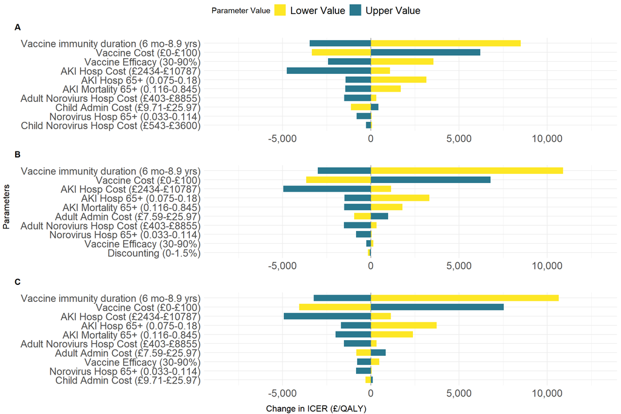

A.V1 under 5, average ICER -1651 B. V2 over 65, average ICER -571 C. V3 under 5 and over 65, average ICER -900

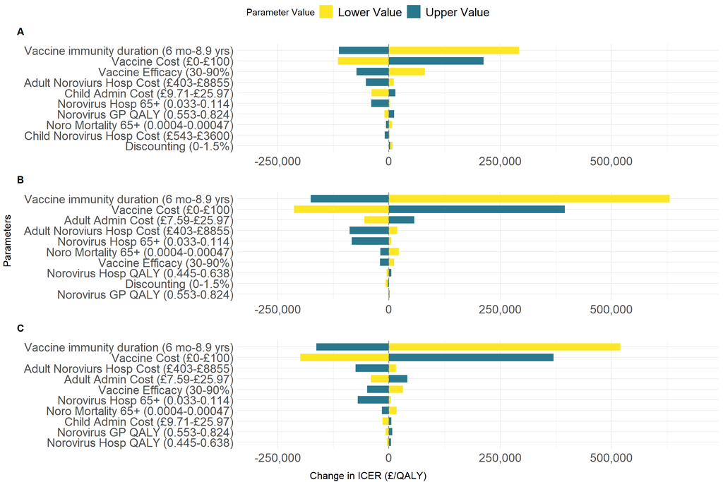

A.V1 under 5, average ICER 54,243 B. V2 over 65, average ICER 198,429 C. V3 under 5 and over 65, average ICER 136,334 ## Probabilistic sensitivity analysis distributions

## Cost-ffectivness plane

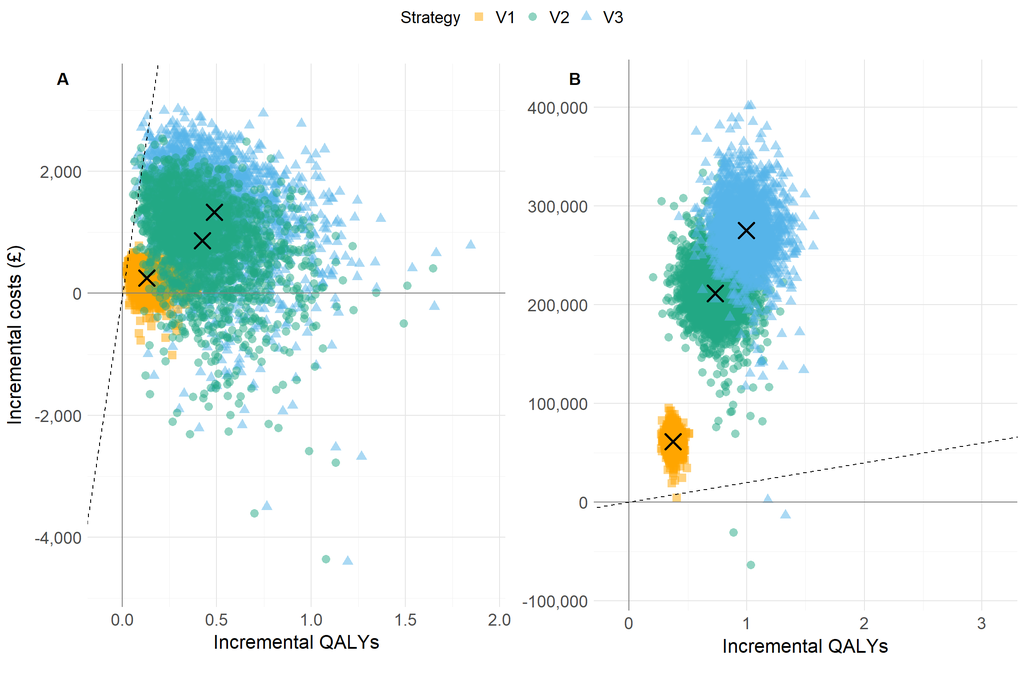

cea plot percentages

```
## Under5 -  Cost Saving:
##  cost_saving    n percent
##            0 1821  0.9105
##            1  179  0.0895
##
##  Under5 -  Cost Effective:
##  cost_effective    n percent
##               0    2   0.001
##               1 1998   0.999
```

```
## Over65 -  Cost Saving:
##  cost_saving    n percent
##            0 1780    0.89
##            1  220    0.11
##
##  Over65 -  Cost Effective:
##  cost_effective    n percent
##               0    7  0.0035
##               1 1993  0.9965
```

```
## Under5 & Over65 -  Cost Saving:
##  cost_saving    n percent
##            0 1872   0.936
##            1  128   0.064
##
##  Under5 & Over65 -  Cost Effective:
##  cost_effective    n percent
##               0    8   0.004
##               1 1992   0.996
```

```
## No AKI Under5 -  Cost Saving:
##  cost_saving    n percent
##            0 2000       1
##
##  No AKI Under5 -  Cost Effective:
##  cost_effective    n percent
##               0 1999  0.9995
##               1    1  0.0005
```

```
## No AKI Over65 -  Cost Saving:
##  cost_saving    n percent
##            0 1998   0.999
##            1    2   0.001
##
##  No AKI Over65 -  Cost Effective:
##  cost_effective    n percent
##               0 1998   0.999
##               1    2   0.001
```

```
## No AKI Under5 & Over65 -  Cost Saving:
##  cost_saving    n percent
##            0 1999  0.9995
##            1    1  0.0005
##
##  No AKI Under5 & Over65 -  Cost Effective:
##  cost_effective    n percent
##               0 1998   0.999
##               1    2   0.001
```

## Incremental Net Monetary Benefit (INMB) for different vaccination strategies

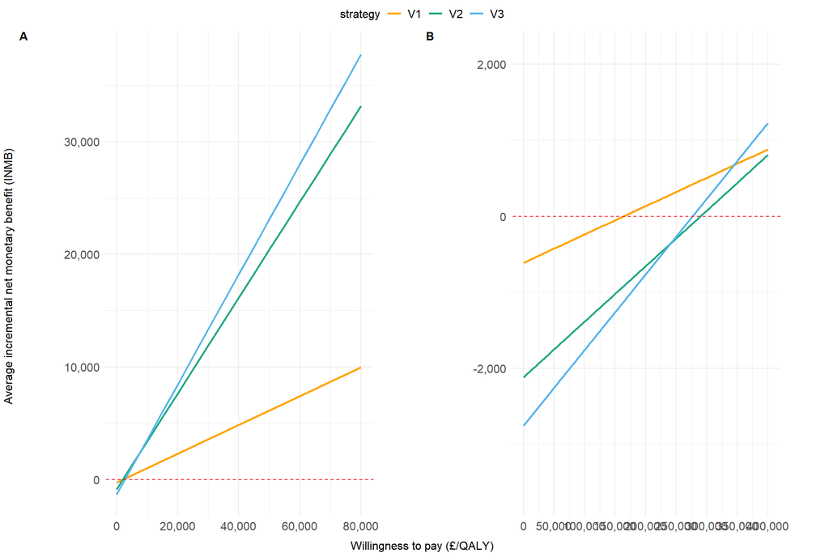

## Cost-effective acceptibility curve and Expected value of perfect information

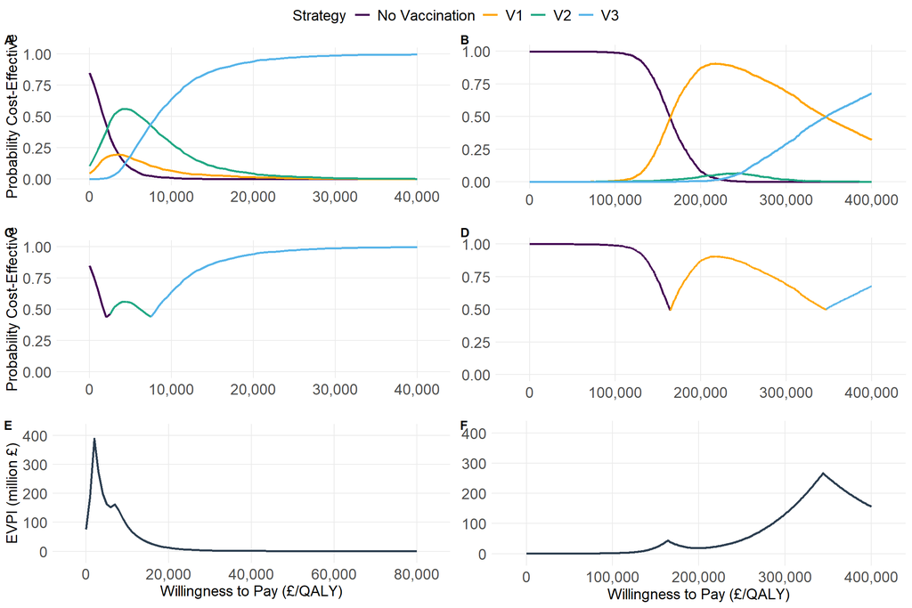

| wtp | Intervention | Probability |
| --- | --- | --- |
| 0 | No Vaccination | 0.8480 |
| 0 | V3 | 0.0005 |
| 0 | V1 | 0.0450 |
| 0 | V2 | 0.1065 |

| wtp | Intervention | Probability |
| --- | --- | --- |
| 20000 | No Vaccination | 0.0005 |
| 20000 | V3 | 0.9390 |
| 20000 | V1 | 0.0155 |
| 20000 | V2 | 0.0450 |

| wtp | Intervention | Probability |
| --- | --- | --- |
| 144000 | No Vaccination | 0.7975 |
| 144000 | V3 | 0.0005 |
| 144000 | V1 | 0.1940 |
| 144000 | V2 | 0.0080 |

| wtp | evpi |
| --- | --- |
| 0 | 75313865 |
| 1000 | 186159586 |
| 2000 | 389102071 |
| 3000 | 276692899 |
| 4000 | 200103236 |
| 5000 | 162734951 |
| 6000 | 152576388 |
| 7000 | 161624788 |
| 8000 | 142172874 |
| 9000 | 111465175 |

[output cut: 71 more lines]

## threshold analysis of AKI hospitalisations rate in over 65

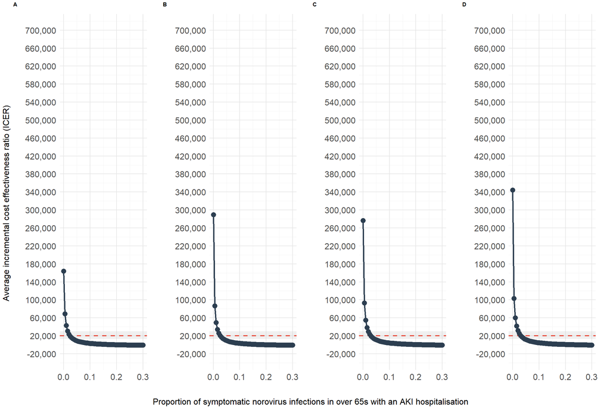

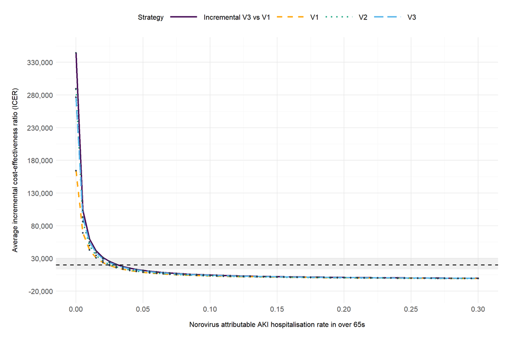

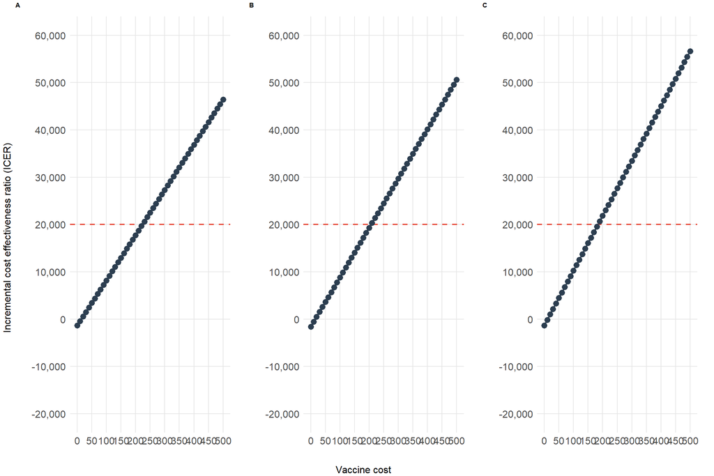

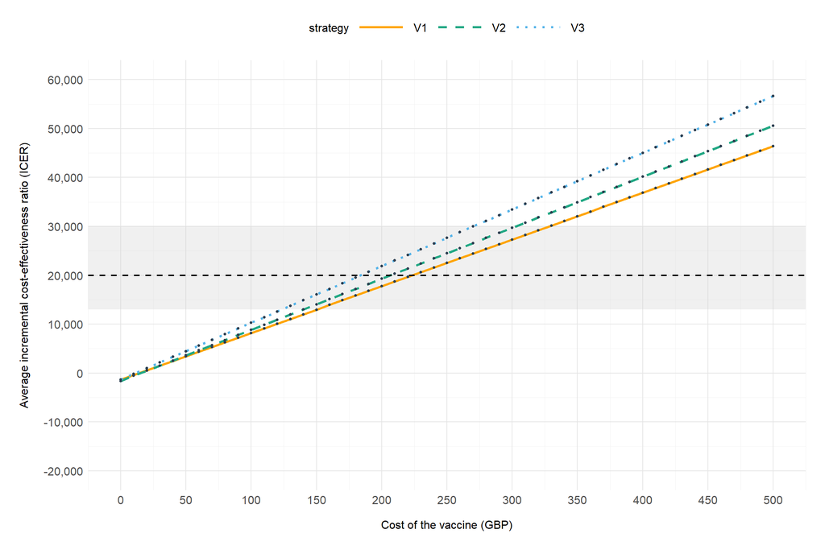

Theshold analysis A. V1 under 5 B. V2 over 65 C. V3 under 5 and 65+